```python
%matplotlib inline
import numpy as np
import matplotlib
import matplotlib.pyplot as plt
import scipy
from scipy import stats
import pandas as pd
```

# 1.

```python
# A1
# Creating the data and appending the 'bad' data points
datarvs = stats.norm.rvs(loc=12,scale=.4,size=100000)
data = np.append([10,10.3,2.1,0,0,15.6,22.3,12.7],datarvs)
```

A2. Statistical question: What is the probability of seeing a bad measurement when the assigned standard for erroneous data is 3 sigma, while sigma is declared as .4? I chose this question to explore how the assinged bad data changes as the amount of sigma is increased and decreased.

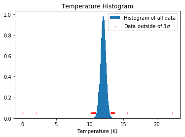

```python
fig, ax = plt.subplots(1, 1)
ax.hist(data,300,alpha=1,density=True,label=r'Histogram of all data');
ax.scatter(data[data < 10.8],np.linspace(0.05,0.05,len(data[data < 10.8])),s=1,c='r',label='Data outside of 3$\sigma$')
ax.scatter(data[data > 13.2],np.linspace(0.05,0.05,len(data[data > 13.2])),s=1,c='r');
plt.legend();
ax.set_xlabel('Temperature (K)')
ax.set_title('Temperature Histogram');
# error in data at say 3 std so <10.8,>13.2
```

The red dots indicate the value of "bad" data corresponding to their respective value on the x-axis. The y-axis has no meaning for the red dots as they are raised to be seen better. The blue histogram is a histogram of all the data.

A3. The integrals from -inf to -3, and from 3 to +inf over the distribution would be the percentage of thrown out data due to it being over 3 sigma away from the mean. Adding the two together gives the probability that a data value is "bad" data.

```python
# A4
baddata = len(data[data>13.2]) + len(data[data<10.8])
gooddata = len(data) - baddata
tn_perc = baddata/len(data)
tp_perc = gooddata/len(data)

bdata = np.array([10,10.3,2.1,0,0,15.6,22.3,12.7])
fN = len(bdata[bdata>13.2]) + len(bdata[bdata<10.8])
fN_perc = fN/len(bdata)
fP = len(bdata) - fN
fP_perc = fP/len(bdata)
pddata = {'True':[tp_perc,tn_perc],'False':[fP_perc,fN_perc]}

df = pd.DataFrame(pddata,index=['Pos','Neg'])
df
```

|  | True | False |
| --- | --- | --- |
| Pos | 0.99719 | 0.125 |
| Neg | 0.00281 | 0.875 |

If I were to choose data greater than 2 sigma to be my standard for "bad" data, then the percentage of "good" data that I generated that was categorized as bad data would be 4.4%, following the sigma percentages on a standard bell curve. Thus the True Negative value is a predictable quantity.

# 2.

1 . The distribution is a 2D gaussian, with the distance between points of sqrt(x^2 + y^2). The movement of an object can then be represented by a Rayleigh distribution, since x and y are both normally distributed with the same sigma value and mean. The Rayleigh distribution is defined as sqrt(x^2 + y^2). Since the gaussian RMS is 1 arcsecond, that will the sigma for the Rayleigh distribution. Since we are looking for values higher than 5 sigma, we would integrate from 5 to +inf.

The question in words would be: Given the background distribution is a Rayleigh distribution, what is the minimum distance we can use to argue for true movement using the 5 sigma value for significance?

2 . We are looking for true movement greater than 5 sigma, so the integral would be from 5 to +inf of the standard gaussian pdf. This would yield a probabilty that we could then use on a rayleigh ppf function to find the value in arcseconds. What is this value?

# 3.

```python
# We are looking for values less than mean which are more signal like.
# The background is poisson due to the fact that we are looking at event counts over a certain interval.
# The pmf will be a poisson distribution with a mean val of the total minutes observed
mean = 1*60*8*15
obs_rate = 6800
```

Question in words: What is the probability that I will see 6800 counts or less from a poisson distribution with a mean of 7200?

Question in math: What is the sigma value for integrating the poisson distribution with mean 7200 from -inf to 6800?

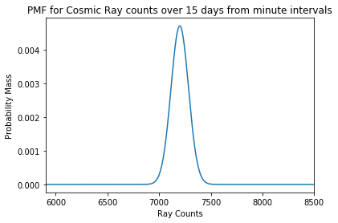

```
The moon shadow has a sigma of -4.750747965777188
```

```python
xvals = np.linspace(0,10000,10001)
pmf = stats.poisson.pmf(xvals,mean)
plt.plot(xvals,pmf)
plt.xlim(5900,8500)
plt.title('PMF for Cosmic Ray counts over 15 days from minute intervals')
plt.xlabel('Ray Counts')
plt.ylabel('Probability Mass');
plt.show();
prob = stats.poisson.cdf(6800,mean)
sigma = stats.norm.ppf(prob)
print('The moon shadow has a sigma of '+str(sigma))
```